# TP2ACP

Enzo Munoz - Hugo Munier - Maxime Guilbaud

##Introduction

Ce travail pratique a pour objectif d’explorer la structure et la variabilité d’un jeu de données multidimensionnel décrivant des mesures environnementales liées à différentes campagnes (BF et CA) et saisons. Face à un grand nombre de variables quantitatives présentant des échelles et des variances très hétérogènes (par exemple, Tot_OcNoDecana vs. B), une analyse factorielle est indispensable pour synthétiser l’information et éviter qu’une seule variable ne domine l’analyse.

Nous avons utilisé l’Analyse en Composantes Principales (ACP) après avoir procédé à une standardisation complète des variables numériques par centrage-réduction. Cette démarche permet de ramener toutes les variables à une même échelle, assurant ainsi une contribution équilibrée de chacune à la construction des axes principaux. L’analyse portera sur l’identification des dimensions fondamentales expliquant la majeure partie de l’inertie, la caractérisation des individus par projection, et l’interprétation des variables qualitatives supplémentaires (SAISON et CAMPAGNE).

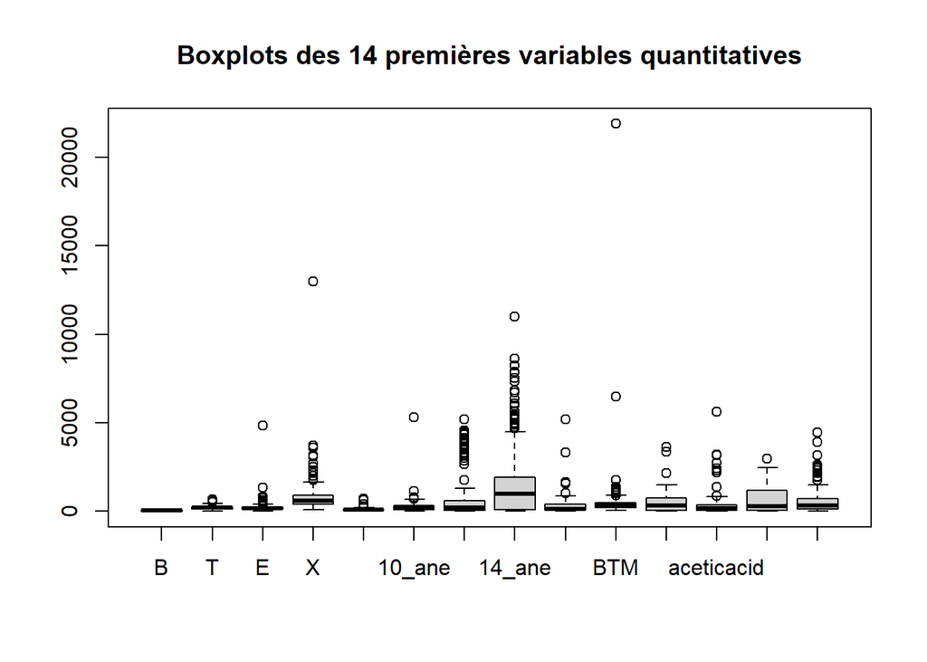

Le box plot nous montre des valeurs atypiques. Notament 2 pour BTM, une pour X, 1 pour 10_ane, 1 pour E

On remarque que pour les données un peu atypique on a un facteur commun qui est le fait que ce soit en campagne CA2 pour la plupart qu’elles sont là. Il faudrait connaître plus d’information sur les conditions dans lesquelles ont été mené ces campagnes.

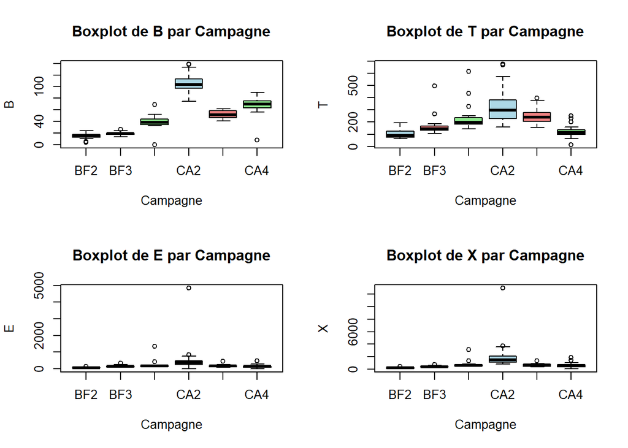

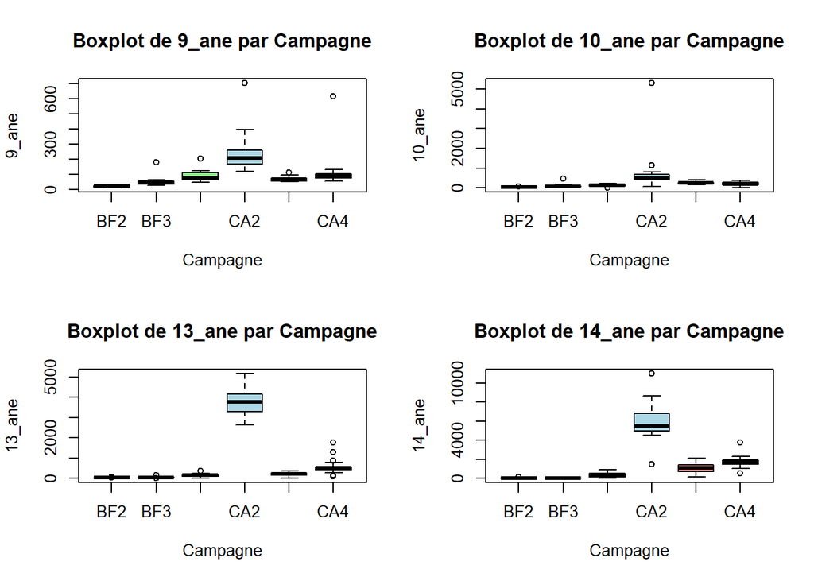

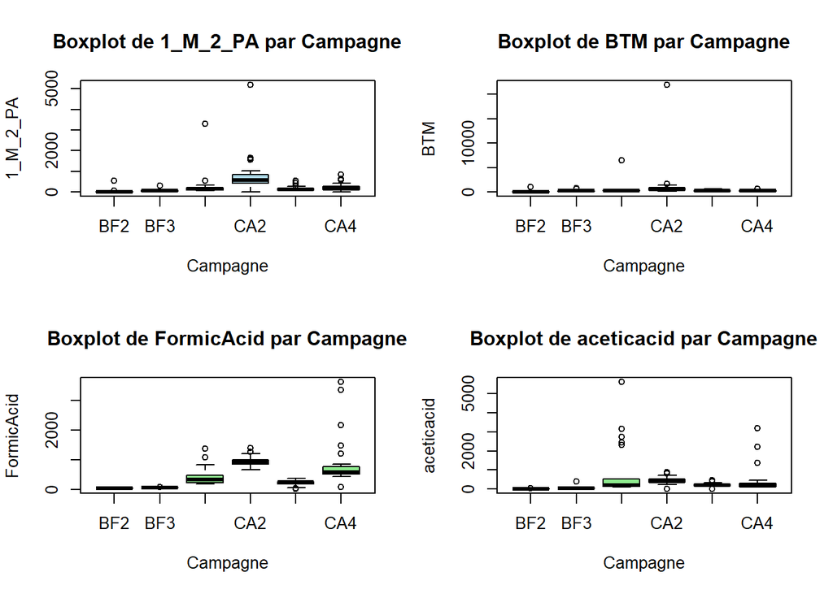

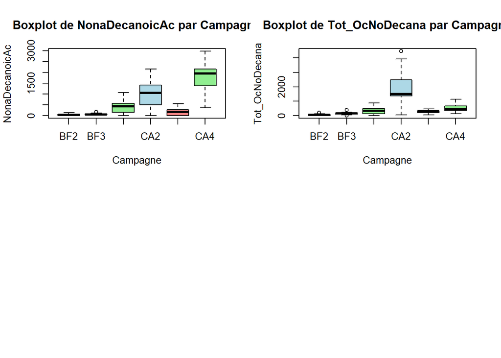

On voit donc bien qu’en fonction de la campagne on obtient pas la même distribution dans nos capteurs chimiques et que la campagne CA2 est la campagne avec la plus grande variance et des valeurs globalement plus haute au niveau des capteurs chimiques.

```
## # A tibble: 2 × 18
##       B     T     E     X `9_ane` `10_ane` `13_ane` `14_ane` `1_M_2_PA`   BTM
##   <dbl> <dbl> <dbl> <dbl>   <dbl>    <dbl>    <dbl>    <dbl>      <dbl> <dbl>
## 1  5.70  133.  149.  448.    31.2     65.8     16.9     33.5       532. 1015.
## 2 33.2   170.  136.  522.    46.1    114.     234.       0         253.  341.
## # ℹ 8 more variables: FormicAcid <dbl>, aceticacid <dbl>, NonaDecanoicAc <dbl>,
## #   Tot_OcNoDecana <dbl>, TYPE <chr>, SAISON <chr>, Campagne <chr>,
## #   Localisation <chr>
```

```
## # A tibble: 4 × 18
##       B     T     E      X `9_ane` `10_ane` `13_ane` `14_ane` `1_M_2_PA`    BTM
##   <dbl> <dbl> <dbl>  <dbl>   <dbl>    <dbl>    <dbl>    <dbl>      <dbl>  <dbl>
## 1  5.70  133.  149.   448.    31.2     65.8     16.9     33.5       532.  1015.
## 2 24.0   159.  210.   535.    58.8    120.      86.3     72.5       316.   764.
## 3 44.1   614. 1345.  3161.   202.       0      168.     560.       3301.  6472.
## 4 94.5   668. 4845. 12988.   702.    5316.    3604.    4967.       5191. 21891.
## # ℹ 8 more variables: FormicAcid <dbl>, aceticacid <dbl>, NonaDecanoicAc <dbl>,
## #   Tot_OcNoDecana <dbl>, TYPE <chr>, SAISON <chr>, Campagne <chr>,
## #   Localisation <chr>
```

```
## # A tibble: 1 × 18
##       B     T     E     X `9_ane` `10_ane` `13_ane` `14_ane` `1_M_2_PA`   BTM
##   <dbl> <dbl> <dbl> <dbl>   <dbl>    <dbl>    <dbl>    <dbl>      <dbl> <dbl>
## 1  33.2  170.  136.  522.    46.1     114.     234.        0       253.  341.
## # ℹ 8 more variables: FormicAcid <dbl>, aceticacid <dbl>, NonaDecanoicAc <dbl>,
## #   Tot_OcNoDecana <dbl>, TYPE <chr>, SAISON <chr>, Campagne <chr>,
## #   Localisation <chr>
```

On a remarqué que dans les données certaines valeurs de type sont des “?” qui signifie un manque d’information sur le type. On compare pour les types des localisations où s’est produit l’anomalie. Pour la localisation P10 tous les types sont sourceindustrie. On a d’autant plus remarqué que pour toutes les localisations on associe qu’un seul type parmi (Rural, urbain, compostage…). On peut donc légitimement imputer le type sourceindustrie.

Pour la localisation P22, on a pas d’autres localisation P22

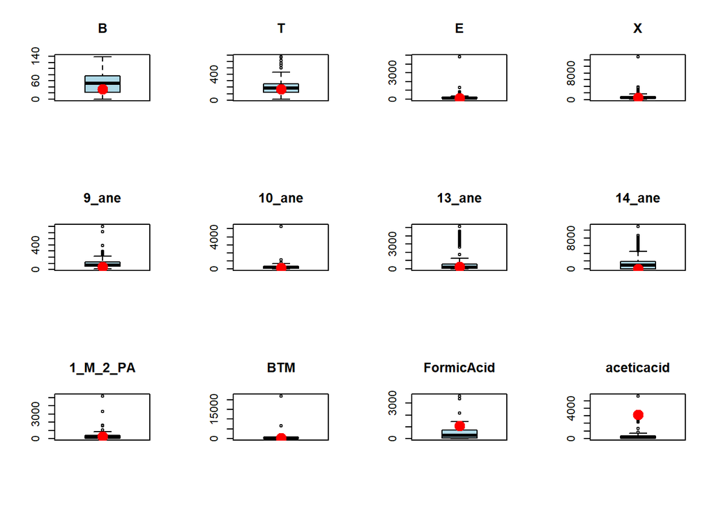

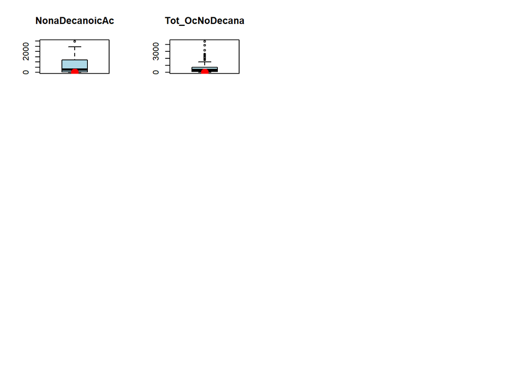

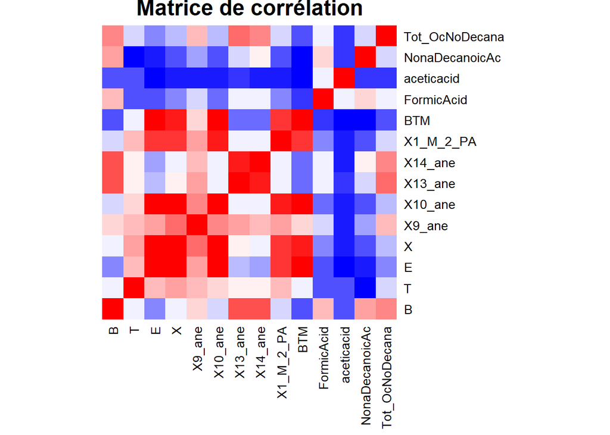

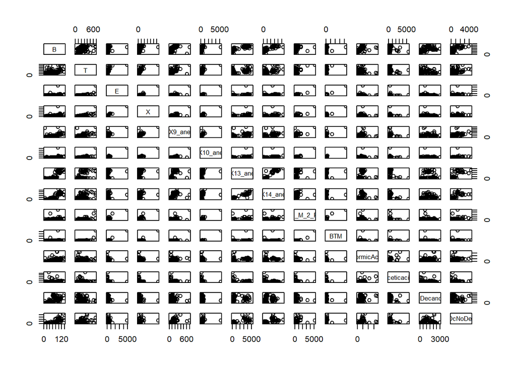

L’information sur la relation entre les deux variables est bien présente des deux côtés de la diagonale, mais les graphiques eux-mêmes sont des “miroirs” avec les axes permutés. Certaines variables ont l’air d’être fortement corrélé. (Exemple : presque une droite entre K13_ane et K14_ane). Par la suite on va vouloir faire des régressions pour prédire les valeurs des variables manquantes.

Notre point de vue est de trouvé les variables qui expliquent le plus la variable manquante mais attention pour valider notre modèle de régression simple il ne faut pas de colinéarité entre les variables qui servent à prédire sinon les prédicteurs auront des erreurs standard importantes à moins d’utiliser des techniques de régression linéaire avancé de type ridge.

```
## NonaDecanoicAc        X13_ane Tot_OcNoDecana     aceticacid              B
##     10.7913669      3.5971223      3.5971223      1.4388489      0.7194245
##              E        X10_ane        X14_ane      X1_M_2_PA              T
##      0.7194245      0.7194245      0.7194245      0.7194245      0.0000000
##              X         X9_ane            BTM     FormicAcid
##      0.0000000      0.0000000      0.0000000      0.0000000
```

Faut-il enlever la colonne NonaDecanonic ? On a choisi que non car potentiellement ça peut être une variable très explicative et qui nous serve plus tard.

Nous avons commencé les régressions avancées avec Xavier Bay. J’ai donc au départ pour m’exercer choisi d’expérimenter la régression Ridge, car certaines variables présentent de la corrélation entre elles. L’objectif ici est de prédire les valeurs manquantes. On procède en partant des colonnes dont le taux de valeurs manquantes est le plus faible, puis on ajuste un modèle de régression linéaire Ridge à partir des observations complètes, en intégrant également les variables catégorielles.

Typiquement, l’ajout de ces variables factorielles revient à introduire un coefficient γ (gamma) : par exemple, si l’individu i est observé en hiver, alors γ = 1, sinon γ = 0. Cette codification (appelée one-hot encoding) multiplie le nombre de variables par le nombre de modalités des facteurs.

Dans ce contexte, il est donc possible que le nombre de prédicteurs p dépasse le nombre d’observations n, ce qui motive l’utilisation d’une régression Lasso, plus adaptée à ce type de situation.

Enfin, certaines lignes présentent plusieurs valeurs manquantes simultanément. Dans ces cas-là, la prédiction n’est pas possible ; la valeur manquante est alors remplacée par la médiane de la colonne correspondante.

```
## Nombre de lignes complètes pour l'entraînement : 109 / 139
```

```
## === IMPUTATION PAR RÉGRESSION RIDGE AVEC VARIABLES CATÉGORIELLES ===
```

```
##
## ━━━━━━━━━━━━━━━━━━━━━━━━━━━━━━━━━━━━━━━━
## Variable : B (0.7% de NA)
## ━━━━━━━━━━━━━━━━━━━━━━━━━━━━━━━━━━━━━━━━
## Dimensions de X_train : n = 109 , p = 51
## R² ajusté : 0.8735
## ✓ Meilleur λ : 3.326212
## ✓ MSE (CV)   : 239.2500
## ✓ R²         : 0.9332
##
## --- Prédiction pour 1 ligne(s) manquante(s) de B ---
##          [,1]    [,2]    [,3] [,4] [,5] [,6] [,7] [,8]     [,9]    [,10]
## [1,] 219.4169 170.542 723.677    0    0    0    0    0 416.6501 267.7346
##         [,11]    [,12]    [,13] [,14] [,15] [,16] [,17] [,18] [,19] [,20] [,21]
## [1,] 197.9145 266.8247 493.3725     0     0     0     1     1     0     1     0
##      [,22] [,23] [,24] [,25] [,26] [,27] [,28] [,29] [,30] [,31] [,32] [,33]
## [1,]     0     0     0     0     0     0     0     0     0     0     0     0
##      [,34] [,35] [,36] [,37] [,38] [,39] [,40] [,41] [,42] [,43] [,44] [,45]
## [1,]     0     0     0     0     0     0     0     0     1     0     0     0
##      [,46] [,47] [,48] [,49] [,50] [,51]
## [1,]     0     0     0     0     0     0
## [1]  1 51
## ✓ 1 valeurs imputées par le modèle Ridge
```

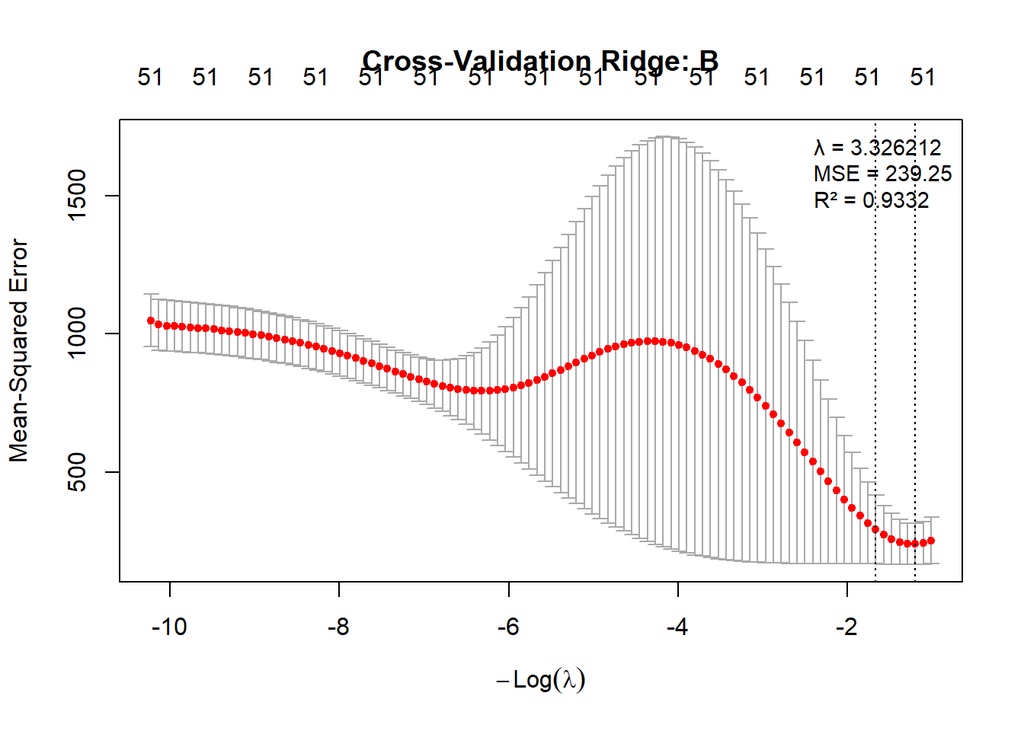

```
##
## ━━━━━━━━━━━━━━━━━━━━━━━━━━━━━━━━━━━━━━━━
## Variable : E (0.7% de NA)
## ━━━━━━━━━━━━━━━━━━━━━━━━━━━━━━━━━━━━━━━━
## Dimensions de X_train : n = 109 , p = 51
## R² ajusté : 0.9756
## ✓ Meilleur λ : 86.909421
## ✓ MSE (CV)   : 87526.4811
## ✓ R²         : 0.9871
##
## --- Prédiction pour 1 ligne(s) manquante(s) de E ---
##          [,1]     [,2]     [,3] [,4] [,5] [,6] [,7] [,8]     [,9]    [,10]
## [1,] 87.26561 354.7874 1777.629    0    0    0    0    0 377.3013 1201.906
##         [,11]    [,12]    [,13] [,14] [,15] [,16] [,17] [,18] [,19] [,20] [,21]
## [1,] 525.8861 1366.798 53.61706     0     1     0     0     0     0     0     1
##      [,22] [,23] [,24] [,25] [,26] [,27] [,28] [,29] [,30] [,31] [,32] [,33]
## [1,]     0     0     0     0     0     0     0     0     1     0     0     0
##      [,34] [,35] [,36] [,37] [,38] [,39] [,40] [,41] [,42] [,43] [,44] [,45]
## [1,]     0     0     0     0     0     0     0     0     0     0     0     0
##      [,46] [,47] [,48] [,49] [,50] [,51]
## [1,]     0     0     0     0     0     0
## [1]  1 51
## ✓ 1 valeurs imputées par le modèle Ridge
```

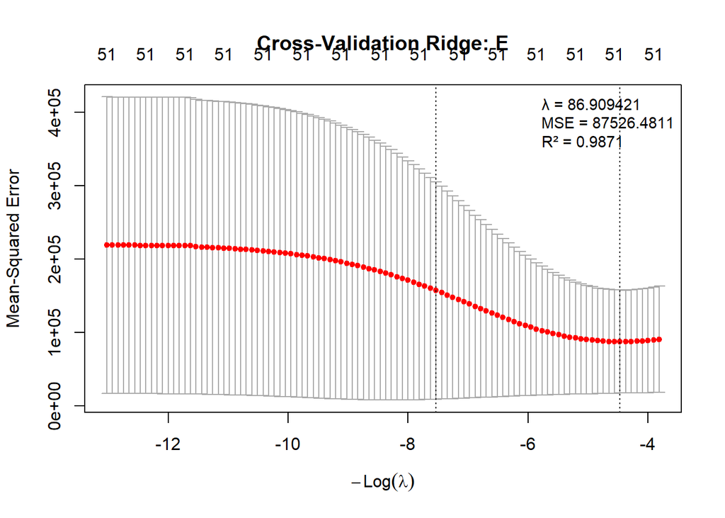

```
##
## ━━━━━━━━━━━━━━━━━━━━━━━━━━━━━━━━━━━━━━━━
## Variable : 10_ane (0.7% de NA)
## ━━━━━━━━━━━━━━━━━━━━━━━━━━━━━━━━━━━━━━━━
## Dimensions de X_train : n = 109 , p = 51
## R² ajusté : 0.9721
## ✓ Meilleur λ : 50.032119
## ✓ MSE (CV)   : 27680.4928
## ✓ R²         : 0.9853
##
## --- Prédiction pour 1 ligne(s) manquante(s) de 10_ane ---
##          [,1]     [,2]     [,3]     [,4] [,5] [,6] [,7] [,8]     [,9]    [,10]
## [1,] 44.09475 613.8331 1345.466 3161.134    0    0    0    0 6472.326 478.4224
##         [,11]   [,12]   [,13] [,14] [,15] [,16] [,17] [,18] [,19] [,20] [,21]
## [1,] 527.9171 844.088 349.297     0     0     1     0     1     0     1     0
##      [,22] [,23] [,24] [,25] [,26] [,27] [,28] [,29] [,30] [,31] [,32] [,33]
## [1,]     0     0     0     0     0     0     0     0     0     0     1     0
##      [,34] [,35] [,36] [,37] [,38] [,39] [,40] [,41] [,42] [,43] [,44] [,45]
## [1,]     0     0     0     0     0     0     0     0     0     0     0     0
##      [,46] [,47] [,48] [,49] [,50] [,51]
## [1,]     0     0     0     0     0     0
## [1]  1 51
## ✓ 1 valeurs imputées par le modèle Ridge
```

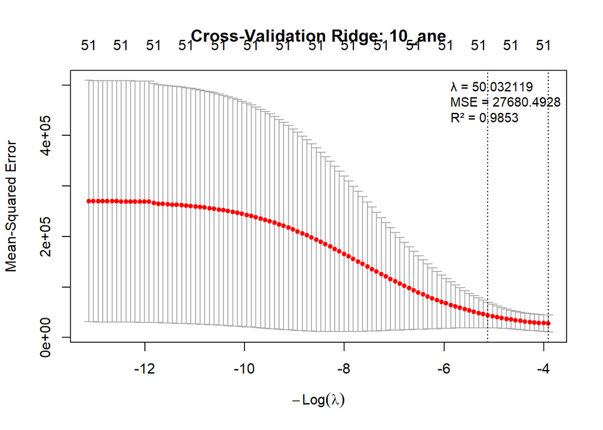

```
##
## ━━━━━━━━━━━━━━━━━━━━━━━━━━━━━━━━━━━━━━━━
## Variable : 14_ane (0.7% de NA)
## ━━━━━━━━━━━━━━━━━━━━━━━━━━━━━━━━━━━━━━━━
## Dimensions de X_train : n = 109 , p = 51
## R² ajusté : 0.9416
## ✓ Meilleur λ : 188.588988
## ✓ MSE (CV)   : 2152652.0456
## ✓ R²         : 0.9692
##
## --- Prédiction pour 1 ligne(s) manquante(s) de 14_ane ---
##          [,1]     [,2]    [,3]     [,4] [,5] [,6] [,7] [,8]     [,9]    [,10]
## [1,] 34.80265 197.8778 174.006 783.7586    0    0    0    0 513.7706 190.4402
##        [,11]    [,12]    [,13] [,14] [,15] [,16] [,17] [,18] [,19] [,20] [,21]
## [1,] 243.331 149.1234 432.0598     0     0     1     0     1     0     1     0
##      [,22] [,23] [,24] [,25] [,26] [,27] [,28] [,29] [,30] [,31] [,32] [,33]
## [1,]     0     0     0     0     0     0     0     0     0     1     0     0
##      [,34] [,35] [,36] [,37] [,38] [,39] [,40] [,41] [,42] [,43] [,44] [,45]
## [1,]     0     0     0     0     0     0     0     0     0     0     0     0
##      [,46] [,47] [,48] [,49] [,50] [,51]
## [1,]     0     0     0     0     0     0
## [1]  1 51
## ✓ 1 valeurs imputées par le modèle Ridge
```

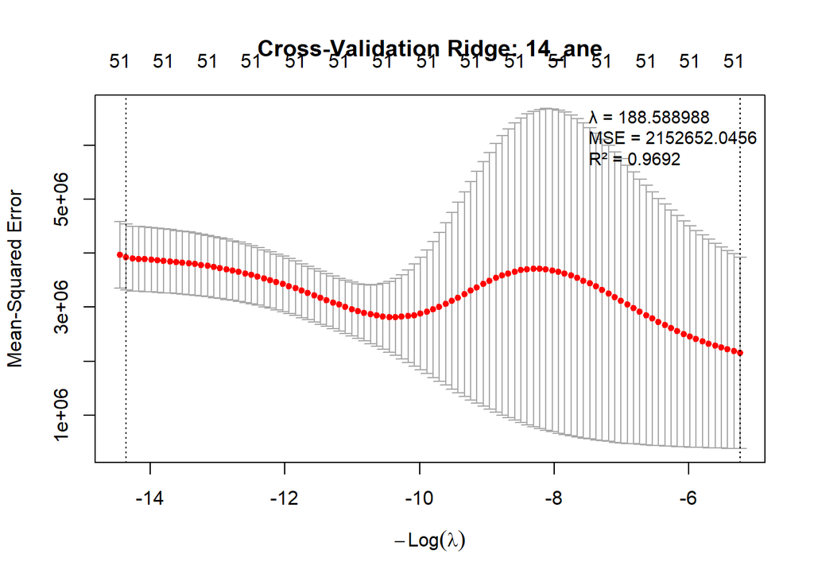

```
##
## ━━━━━━━━━━━━━━━━━━━━━━━━━━━━━━━━━━━━━━━━
## Variable : 1_M_2_PA (0.7% de NA)
## ━━━━━━━━━━━━━━━━━━━━━━━━━━━━━━━━━━━━━━━━
## Dimensions de X_train : n = 109 , p = 51
## R² ajusté : 0.8678
## ✓ Meilleur λ : 433.711962
## ✓ MSE (CV)   : 35482.5013
## ✓ R²         : 0.9302
##
## --- Prédiction pour 1 ligne(s) manquante(s) de 1_M_2_PA ---
##          [,1]     [,2]     [,3]     [,4] [,5] [,6] [,7] [,8]     [,9]    [,10]
## [1,] 103.4176 273.9046 371.1951 1114.945    0    0    0    0 366.5202 1016.273
##         [,11]    [,12]    [,13] [,14] [,15] [,16] [,17] [,18] [,19] [,20] [,21]
## [1,] 498.8347 1046.247 981.1778     0     1     0     0     0     0     0     1
##      [,22] [,23] [,24] [,25] [,26] [,27] [,28] [,29] [,30] [,31] [,32] [,33]
## [1,]     0     0     0     0     0     0     0     0     0     0     0     0
##      [,34] [,35] [,36] [,37] [,38] [,39] [,40] [,41] [,42] [,43] [,44] [,45]
## [1,]     0     1     0     0     0     0     0     0     0     0     0     0
##      [,46] [,47] [,48] [,49] [,50] [,51]
## [1,]     0     0     0     0     0     0
## [1]  1 51
## ✓ 1 valeurs imputées par le modèle Ridge
```

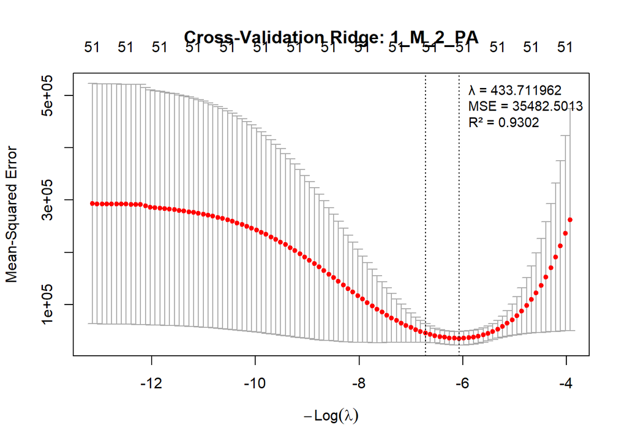

```
##
## ━━━━━━━━━━━━━━━━━━━━━━━━━━━━━━━━━━━━━━━━
## Variable : aceticacid (1.4% de NA)
## ━━━━━━━━━━━━━━━━━━━━━━━━━━━━━━━━━━━━━━━━
## Dimensions de X_train : n = 109 , p = 51
## R² ajusté : -0.3679
## ✓ Meilleur λ : 1704.282068
## ✓ MSE (CV)   : 493452.7896
## ✓ R²         : 0.2781
## ⚠️  R² < 0.5 → Imputation par médiane (modèle non validé)
## ✓ 2 valeurs imputées par la médiane
##
## ━━━━━━━━━━━━━━━━━━━━━━━━━━━━━━━━━━━━━━━━
## Variable : 13_ane (3.6% de NA)
## ━━━━━━━━━━━━━━━━━━━━━━━━━━━━━━━━━━━━━━━━
## Dimensions de X_train : n = 109 , p = 51
## R² ajusté : 0.9377
## ✓ Meilleur λ : 268.024503
## ✓ MSE (CV)   : 140969.7120
## ✓ R²         : 0.9671
##
## --- Prédiction pour 5 ligne(s) manquante(s) de 13_ane ---
##          B         T         E        X 9_ane 10_ane 14_ane 1_M_2_PA       BTM
## 1  4.32871  91.82879  24.75034  77.5317     0      0      0        0  36.62081
## 2 13.14378  92.53471  62.56220 199.8306     0      0      0        0  97.76965
## 3 17.88166 144.86812 124.82776 362.1512     0      0      0        0 257.30822
## 5 51.52353 231.82111 157.51814 617.0749     0      0      0        0 350.54174
##   FormicAcid aceticacid NonaDecanoicAc Tot_OcNoDecana TYPEcompostage TYPErural
## 1   18.30971  34.362957       14.16639       25.11264              1         0
## 2   31.42189   9.894403       37.62557       35.01816              0         0
## 3   48.12994  40.927028      101.41193      186.14622              0         1
## 5  242.72050 157.640179      303.55189      393.04948              0         0
##   TYPEsourceindustrie TYPEurbain SAISONhiver CampagneBF3 CampagneCA1
## 1                   0          0           1           0           0
## 2                   0          1           1           0           0
## 3                   0          0           1           1           0
## 5                   0          1           1           0           0
##   CampagneCA2 CampagneCA3 CampagneCA4 LocalisationP02 LocalisationP03
## 1           0           0           0               1               0
## 2           0           0           0               0               0
```

[output cut: 23 more lines]

[output not shown]

```
## ✓ 5 valeurs imputées par le modèle Ridge
```

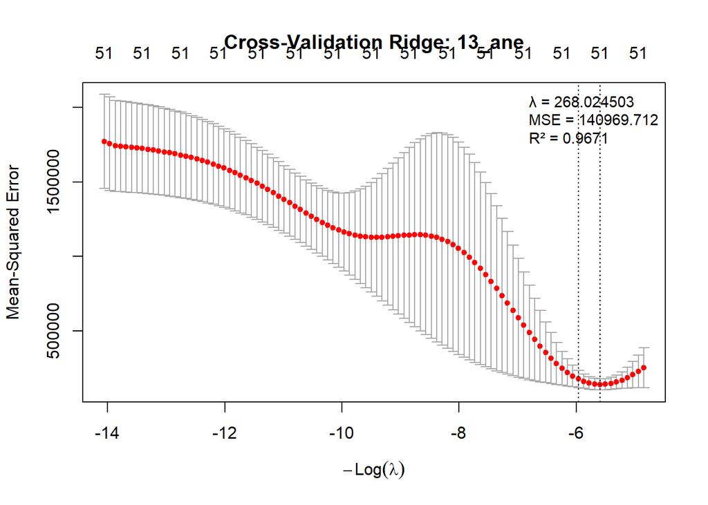

```
##
## ━━━━━━━━━━━━━━━━━━━━━━━━━━━━━━━━━━━━━━━━
## Variable : Tot_OcNoDecana (3.6% de NA)
## ━━━━━━━━━━━━━━━━━━━━━━━━━━━━━━━━━━━━━━━━
## Dimensions de X_train : n = 109 , p = 51
## R² ajusté : 0.7416
## ✓ Meilleur λ : 68.717155
## ✓ MSE (CV)   : 379897.6460
## ✓ R²         : 0.8636
##
## --- Prédiction pour 5 ligne(s) manquante(s) de Tot_OcNoDecana ---
##           B        T        E        X 9_ane 10_ane 13_ane 14_ane 1_M_2_PA
## 1 20.726276 195.5374 121.4418 403.2321     0      0      0      0        0
## 2  5.696469 132.8071 148.7440 447.7892     0      0      0      0        0
## 3 18.960528 144.9126 136.2257 393.4663     0      0      0      0        0
```

[output cut: 64 more lines]

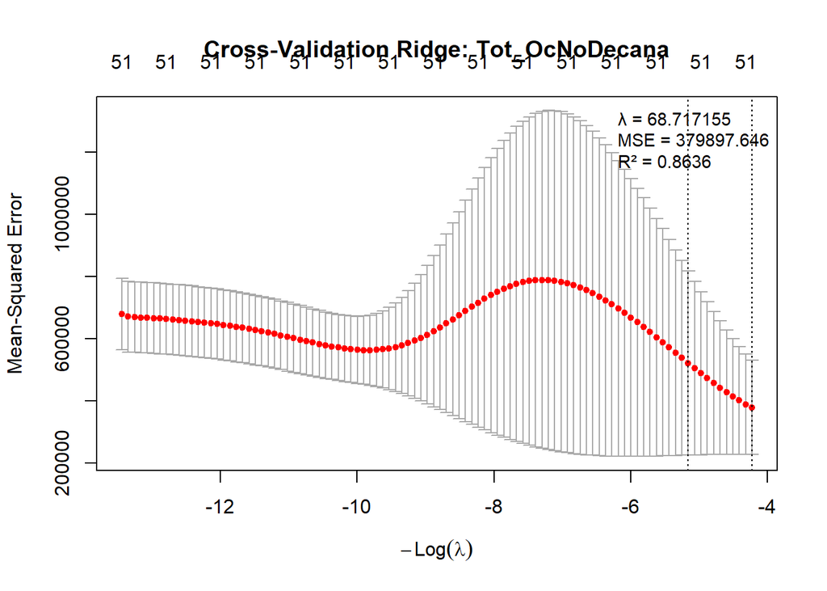

```
##
## ━━━━━━━━━━━━━━━━━━━━━━━━━━━━━━━━━━━━━━━━
## Variable : NonaDecanoicAc (10.8% de NA)
## ━━━━━━━━━━━━━━━━━━━━━━━━━━━━━━━━━━━━━━━━
## Dimensions de X_train : n = 109 , p = 51
## R² ajusté : 0.1489
## ✓ Meilleur λ : 3375.763552
## ✓ MSE (CV)   : 522802.0599
## ✓ R²         : 0.5508
## ⚠️  R² < 0.5 → Imputation par médiane (modèle non validé)
## ✓ 15 valeurs imputées par la médiane
```

```
##
##
## === RÉSUMÉ DES PERFORMANCES ===
```

```
##         Variable NA_percent Best_Lambda        MSE        R2     R2_adj
## 1              B  0.7194245    3.326212     239.25 0.9332425  0.8735122
## 2              E  0.7194245   86.909421   87526.48 0.9871058  0.9755689
## 3         10_ane  0.7194245   50.032119   27680.49 0.9852736  0.9720973
## 4         14_ane  0.7194245  188.588988 2152652.05 0.9691665  0.9415786
## 5       1_M_2_PA  0.7194245  433.711962   35482.50 0.9302374  0.8678182
## 6     aceticacid  1.4388489 1704.282068  493452.79 0.2780613 -0.3678838
## 7         13_ane  3.5971223  268.024503  140969.71 0.9671264  0.9377132
## 8 Tot_OcNoDecana  3.5971223   68.717155  379897.65 0.8636000  0.7415578
## 9 NonaDecanoicAc 10.7913669 3375.763552  522802.06 0.5507976  0.1488796
##               Method
## 1              Ridge
## 2              Ridge
## 3              Ridge
## 4              Ridge
## 5              Ridge
## 6 Mediane (R² < 0.5)
## 7              Ridge
## 8              Ridge
## 9 Mediane (R² < 0.5)
```

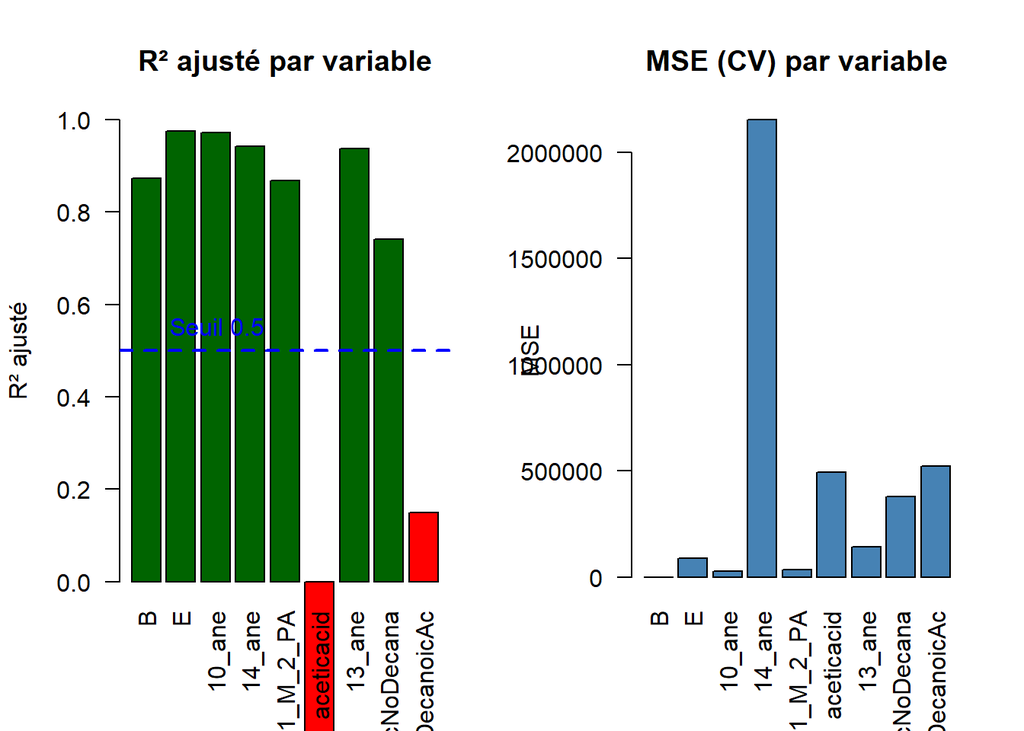

```
##
## ✅ Imputation terminée !
```

```
## Note : Les variables catégorielles (TYPE, Campagne, SAISON, Localisation)
```

```
##        ont été intégrées via one-hot encoding (γ = 1 si modalité présente, 0 sinon)
```

```
##        Seules les lignes complètes ont été utilisées pour l'entraînement
```

```
##              B              T              E              X          9_ane
##              0              0              0              0              0
##         10_ane         13_ane         14_ane       1_M_2_PA            BTM
##              0              0              0              0              0
##     FormicAcid     aceticacid NonaDecanoicAc Tot_OcNoDecana           TYPE
##              0              0              0              0              0
##         SAISON       Campagne   Localisation
##              0              0              0
```

```
##
##         compostage rural sourceindustrie urbain
##   été            4    24               3     26
##   hiver          7    34               7     34
```

```
##
##         compostage      rural sourceindustrie     urbain
##   été   0.02877698 0.17266187      0.02158273 0.18705036
##   hiver 0.05035971 0.24460432      0.05035971 0.24460432
```

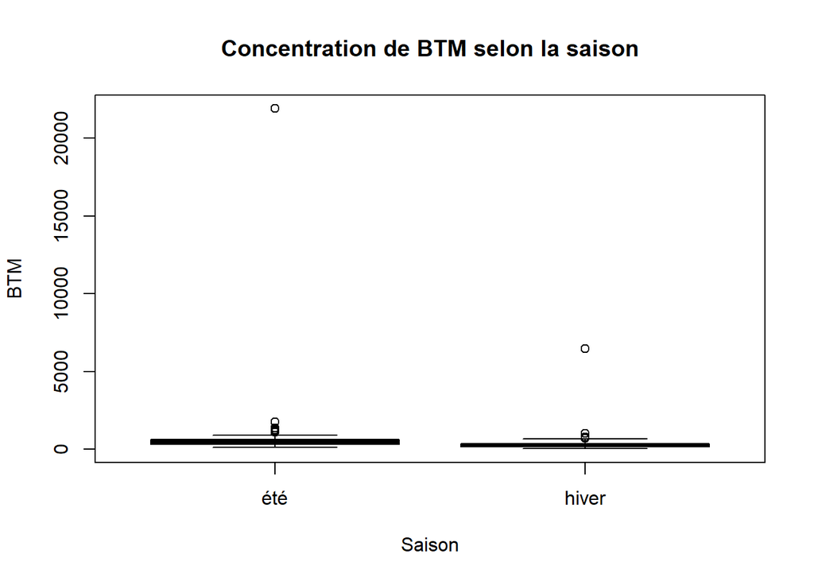

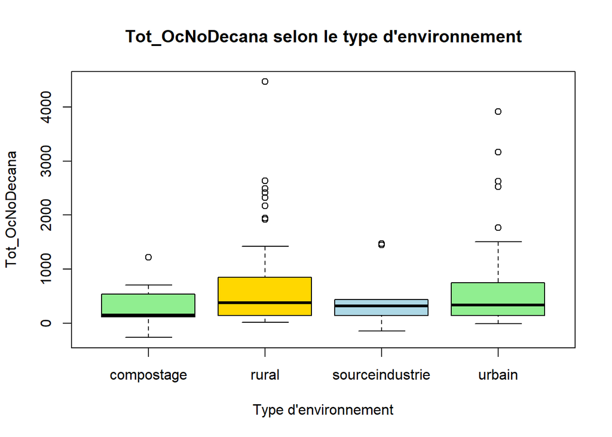

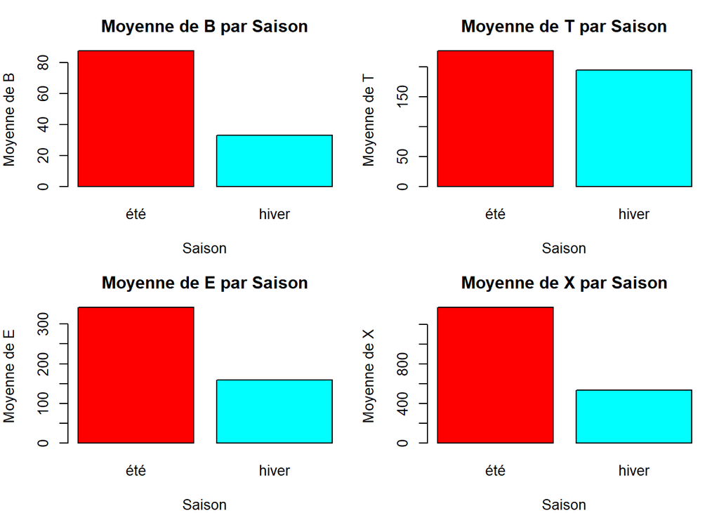

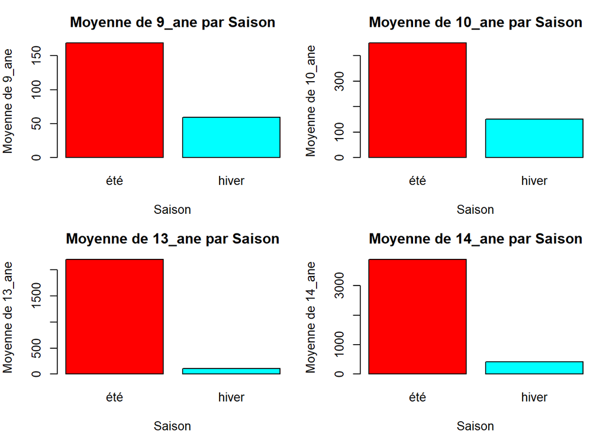

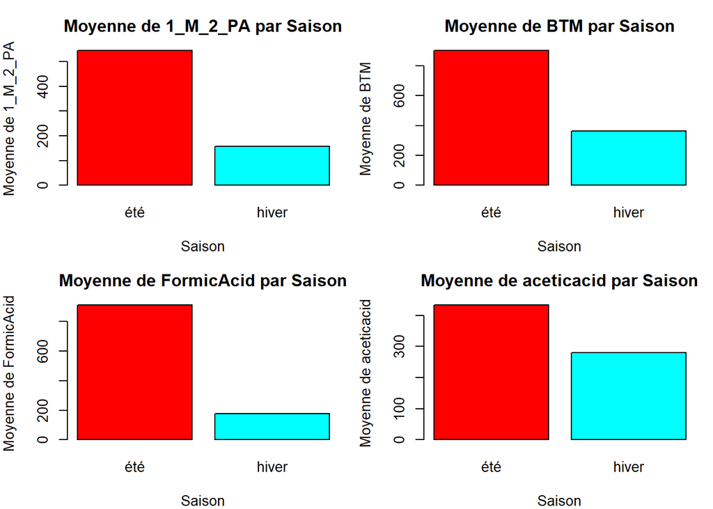

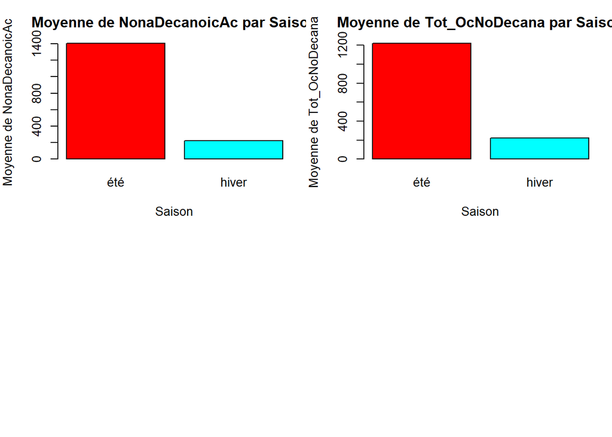

Pour répondre à la question de la différence dans nos données entre hiver et été les histogrammes montrent une augmentation des concentrations dans l’ensemble des composés chimiques captés. On va le voir aussi avec le graphe de projection sur les 2 composantes principales.

En faisant une première ACP on s’est rendu compte qu’un individu était très à l’écart de l’emble des autres données.

On voit que l’individu a été mesuré pendant la campagne CA2, en été qu’on a déjà repéré auparavant comme ayant des relevés pour les capteurs chimiques plus haut que les autres.

On supprime la variable qualitative de localisation qui nous apporte pas plus d’information par rapport aux type d’environnement.

```
## [1] "Individu avec le max sur Dim.1 (Index): 77"
```

```
## [1] "Ses coordonnées (Dim.1 et Dim.2) sont :"
```

```
##     Dim.1     Dim.2
##  20.29857 -12.38978
```

```
## [1] "Individu avec le min sur Dim.2 (Index): 77"
```

```
##           B        T        E        X    9_ane   10_ane   13_ane   14_ane
## 77 94.52356 668.1687 4844.956 12987.88 702.2398 5316.464 3604.148 4966.982
##    1_M_2_PA      BTM FormicAcid aceticacid NonaDecanoicAc Tot_OcNoDecana
## 77 5191.044 21891.22   963.8355   356.8943       765.9649       1475.405
##               TYPE SAISON Campagne Localisation
## 77 sourceindustrie    été      CA2          P10
```

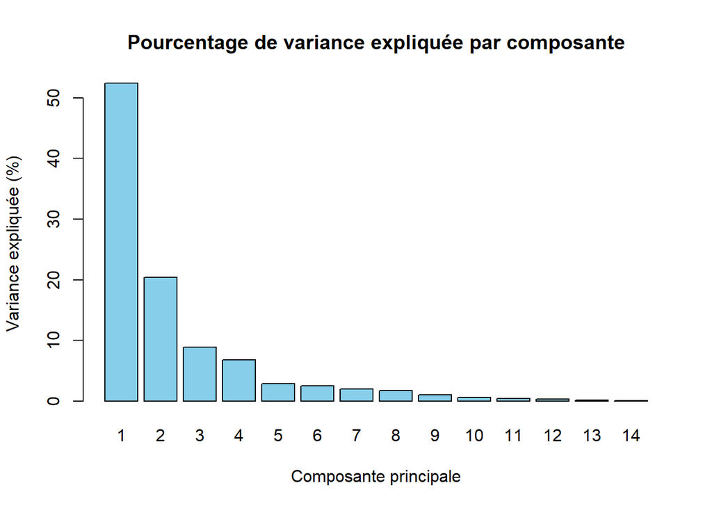

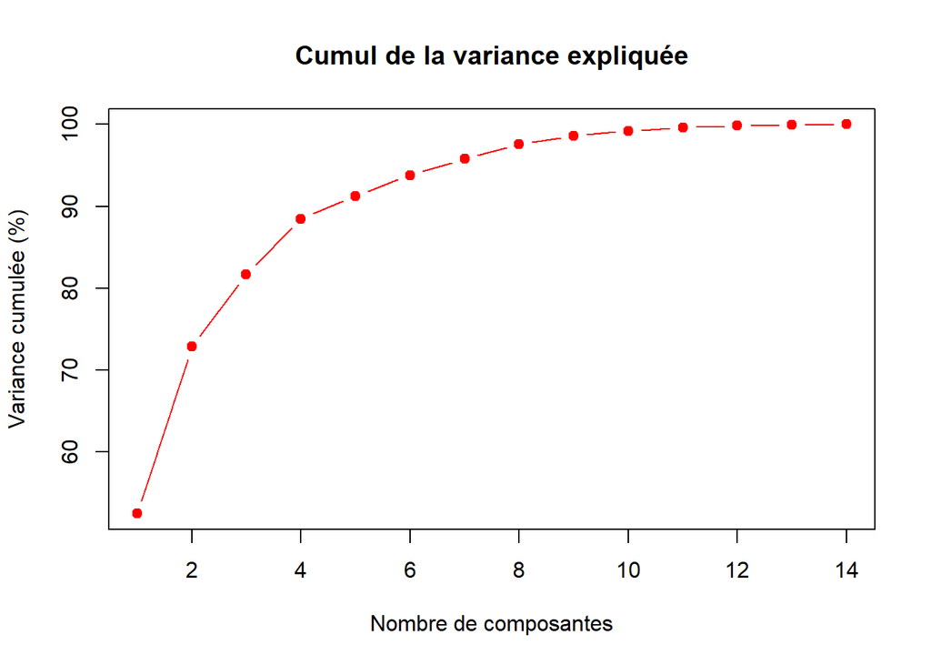

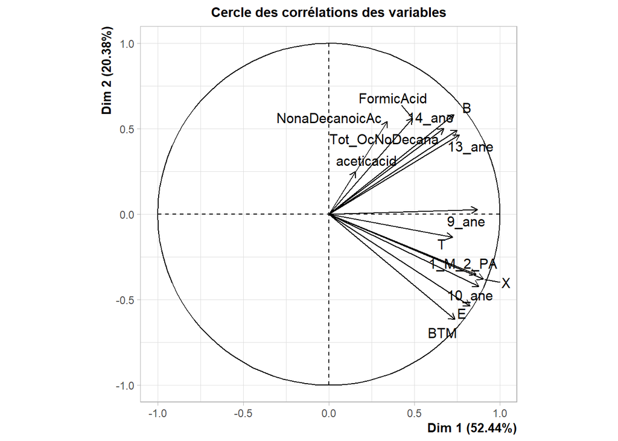

Avant de réaliser l’ACP, les données ont été normalisées. Cette étape est essentielle afin d’éviter la sur-pondération des variables présentant une forte variance. Par exemple, la variable Tot_OcNoDecana a une amplitude interquartile (3Q – 1Q) d’environ 560, tandis que la variable B n’a qu’une amplitude de 71. Sans normalisation, la première aurait donc une influence disproportionnée sur les axes factoriels. J’ai donc appliqué un centrage-réduction linéaire à l’ensemble des variables quantitatives. De plus, les unités de mesure ne sont pas nécessairement homogènes entre les variables, ce qui renforce la nécessité de cette étape.

La décroissance de la variance expliquée par les composantes principales suit une tendance exponentielle sans cassure nette. On peut alors retenir soit les composantes dont les valeurs propres sont supérieures à 1, soit celles qui, cumulées, expliquent au moins 90 % de la variance totale.

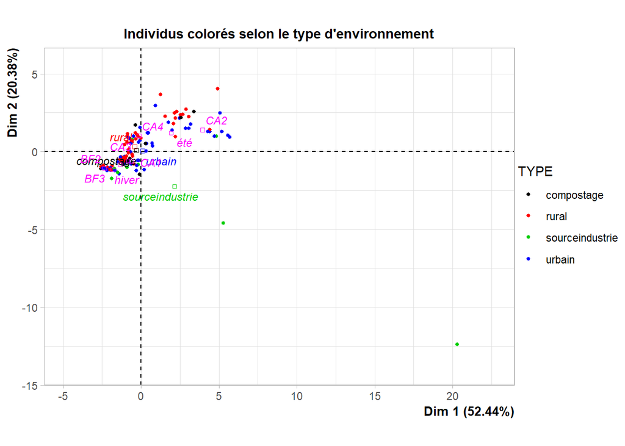

Sur la projection des individus sur les deux premières composantes principales, on observe que l’axe des abscisses sépare nettement les échantillons provenant de sources industrielles : environ 80 % d’entre eux se situent dans la partie inférieure du graphique. Les points situés à l’extrémité droite et en bas du plan factoriel semblent isolés et pourraient correspondre à des observations atypiques ou extrêmes.

Avant de décider de les retirer, il est important de vérifier leur signification réelle :

S’ils représentent des mesures valides mais issues d’un contexte industriel spécifique, les conserver pourrait biaiser l’analyse globale des campagnes non industrielles.

En revanche, s’il s’agit de valeurs aberrantes ou de conditions expérimentales non représentatives, il est justifié de les exclure pour obtenir une interprétation plus fidèle de la structure principale des données.

Dans ce cas, il serait donc pertinent de tester une ACP sans ces individus extrêmes afin de comparer la stabilité des axes et l’évolution de la variance expliquée.

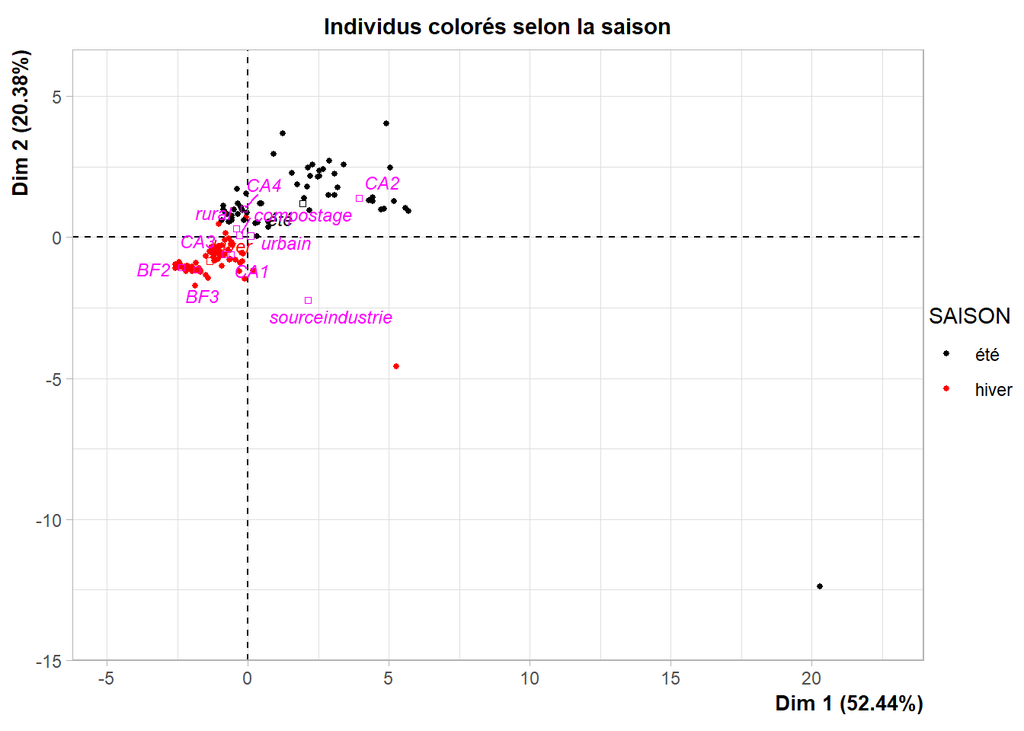

Sur cette nouvelle représentation, on observe une séparation nette entre les saisons d’été et d’hiver, matérialisée par l’axe des abscisses. Cependant, un individu situé en bas à droite semble mal classé : bien qu’il appartienne à la saison d’été, il se positionne du côté inférieur de l’axe, associé plutôt aux observations hivernales.

[figure not shown]

On observe sur ce graphique que les différentes campagnes se distinguent bien les unes des autres. Cependant, deux individus situés à l’extrémité droite perturbent la lecture globale : ils semblent concentrer une grande part de la variance, ce qui masque la structure générale des autres observations. Nous avons donc choisi de les retirer afin de mieux interpréter la variabilité entre les individus « typiques ». Cette décision est justifiée par le fait que ces deux points proviennent d’un contexte industriel particulier et présentent des valeurs nettement plus extrêmes que le reste des données.

```
## → Suppression des individus les plus bas sur Dim.2 : 77 et 55
```

```
## Coordonnées respectives :
```

```
##        Dim.1      Dim.2
## 77 20.298568 -12.389781
## 55  5.276519  -4.589642
```

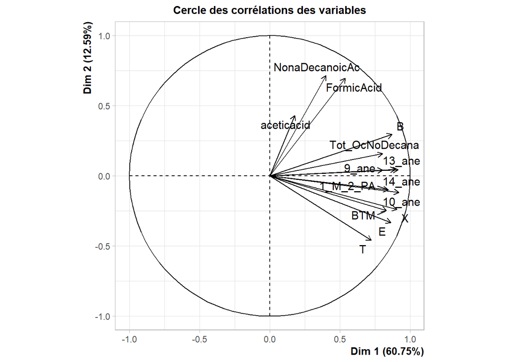

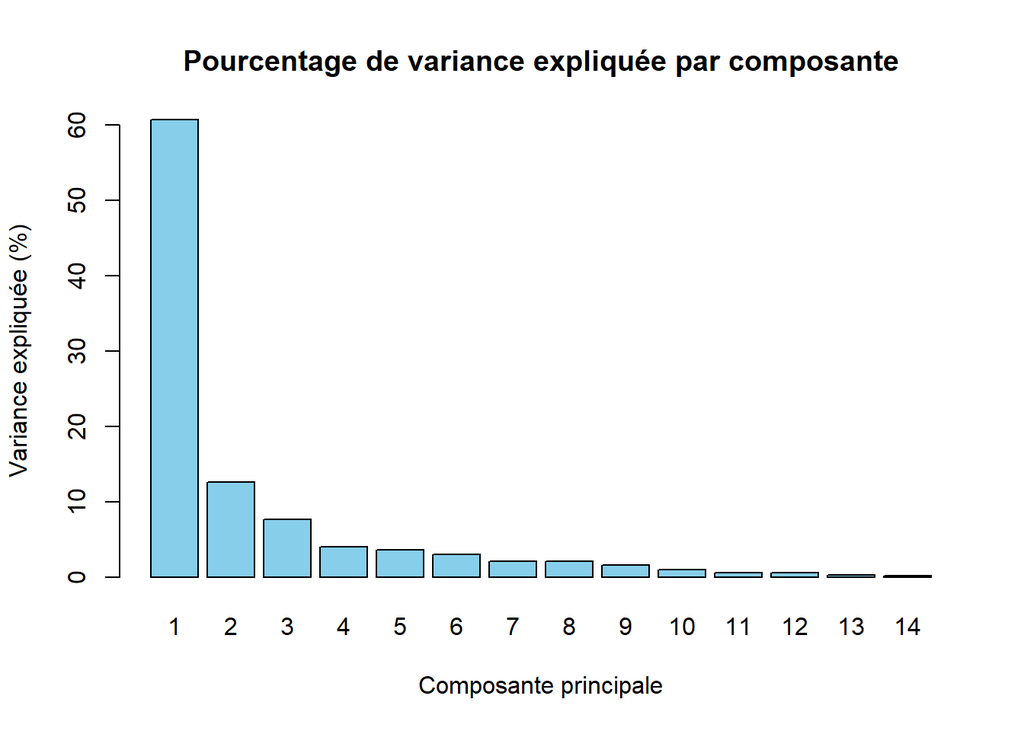

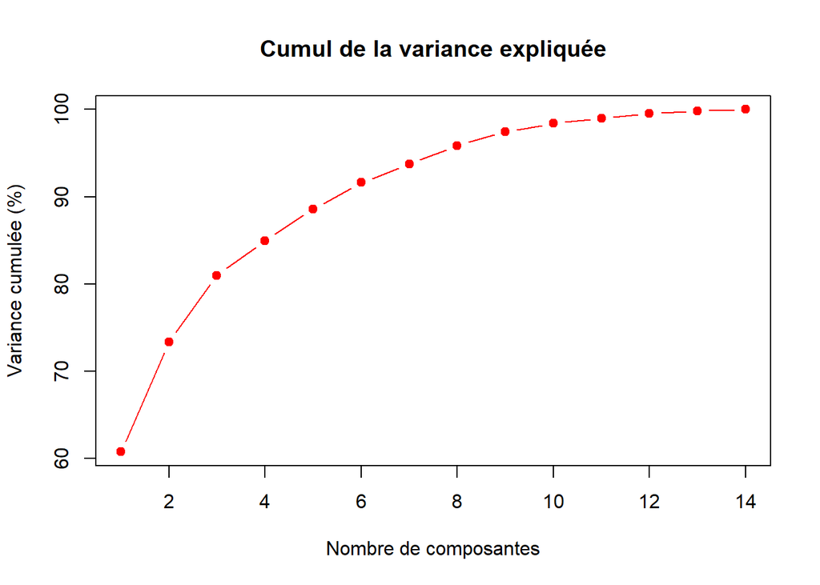

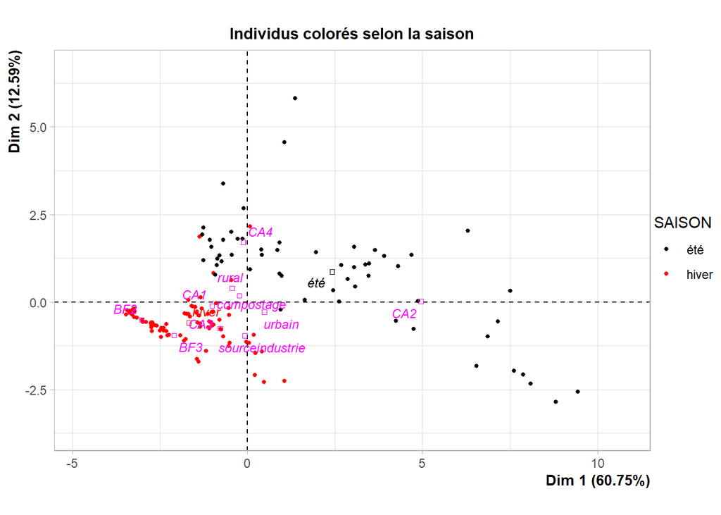

[figure not shown]

On ne voit pas vraiment les catégories qui se dégage dans cette configuration.

[figure not shown]

On voit encore mieux cette séparation des campagnes après avoir enlever 2 données Comme les saisons ont déjà bien été séparé. On va s’interreser aux autres en séparant par saison.

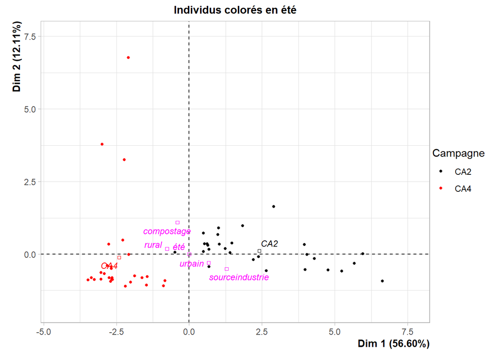

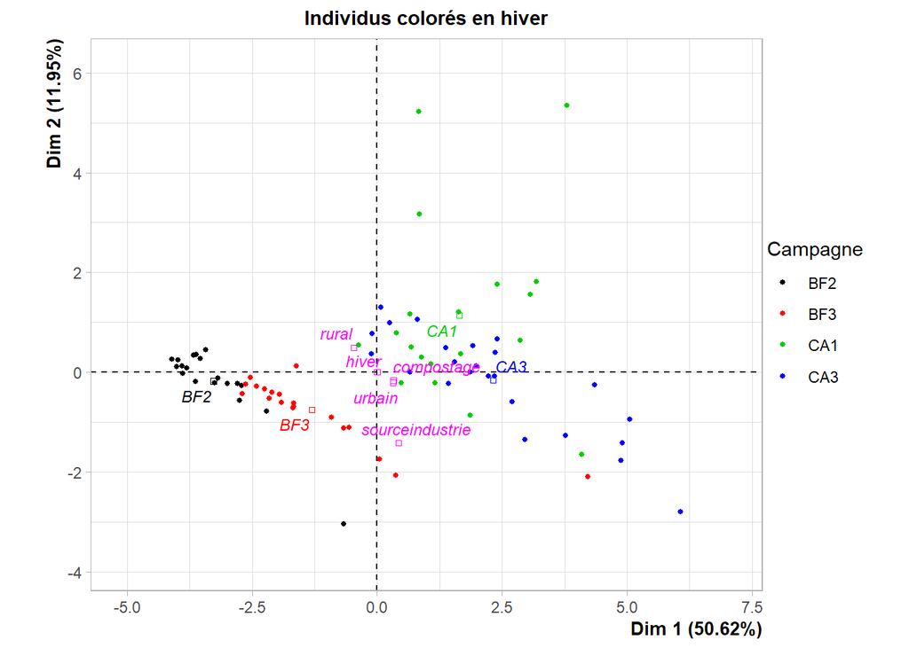

Une limite de ce jeu de données, soulevée par cette analyse, est l’absence de mesures pour la campagne BF durant la saison estivale. Cette lacune dans le plan d’échantillonnage empêche une comparaison directe de cette campagne entre les deux saisons, ce qui aurait pu fournir des informations complémentaires sur la variabilité saisonnière spécifique à ce type d’environnement.

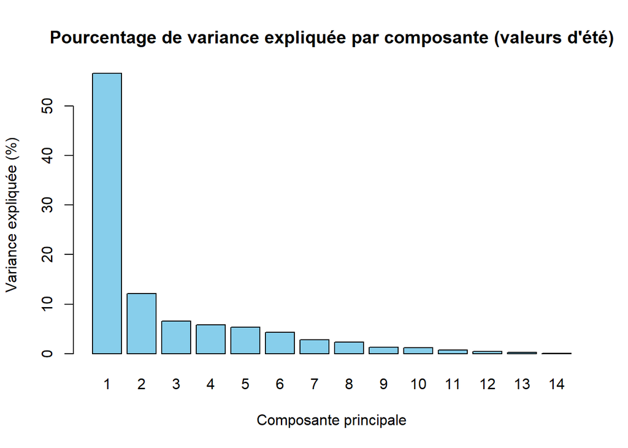

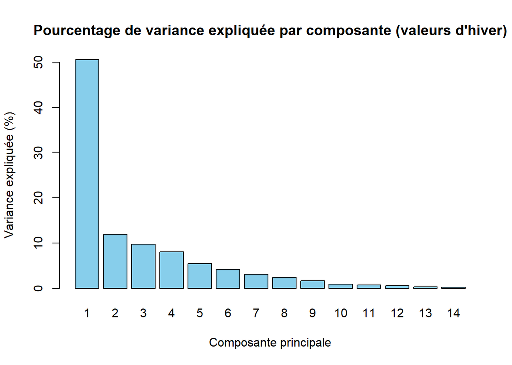

##Conclusion

Ce TP a permis de décomposer la structure du jeu de données grâce à l’ACP, démontrant l’efficacité de cette méthode pour la réduction de dimensionnalité. La standardisation préalable s’est avérée cruciale pour garantir l’équité des contributions des variables, en dépit de leurs échelles initiales très différentes.

Les principaux résultats confirment que la saisonnalité est le facteur de variation le plus déterminant. L’analyse révèle notamment, pour la série d’hiver, une nette discrimination des individus selon leur campagne (BF vs. CA) sur le premier axe. Néanmoins, une limite méthodologique a été mise en lumière : l’absence de la campagne BF en été restreint notre capacité à généraliser l’impact saisonnier pour cette campagne spécifique.

En perspective, il serait pertinent de compléter l’échantillonnage pour les campagnes manquantes afin de valider et d’affiner l’interprétation des effets croisés entre la saison et le type de campagne.